# The Result of Benchmarking a Hierarchical Clustering

## Abstract

I implemented a hierarchical clustering algorithm and tested it. I inspected the effect of the number of input rows in Experiment 1. The more the number of input data rows increases, the more the training execution time increases linearly. And I inspected the effect of the input vector's dimensions in Experiment 2. The more the number of input vector's dimensions increases, the training execution time increases linearly. And I inspected the effect of the number of CPU cores in Experiment 3. The more the number of CPU cores on the Apache Spark cluster, the more the training execution time decrease. However if the number of CPU cores is large against the input data size, the time is saturant. Ant I checked the accuracy of the hierarchical clustering model. As a result of the experiments, it is good enought.

## Spark Cluster Specification

I run the hierarchical clustering application on EC2 under the below specifaction.

- Master Instance Type: r3.large
- Slave Instance Type: r3.8xlarge
  - Cores: 32
  - Memory: 244GB
- # of Slaves: 5
  - Total Cores: 160
  - Total Memory: 1220GB

## Experiment 1: The Effects of Tne Number of Input Data Rows

### Experimental Setup

I execute my hierarchical clustering, changing the some parameters as bellow. The data had been generated randomly. And then I measured the execution time for training each model.

- # Used Cores: 160
- # Clusters: 5, 10, 20, 50, 100
- # Rows: 100000, 500000, 1000000, 5000000, 10000000
- # Dimensions: 100

### The Result of Training Execution Time

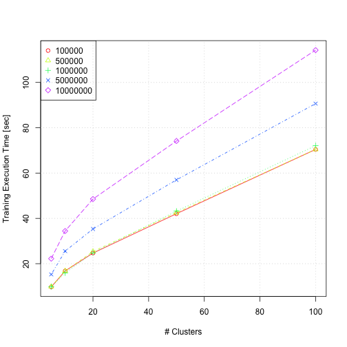

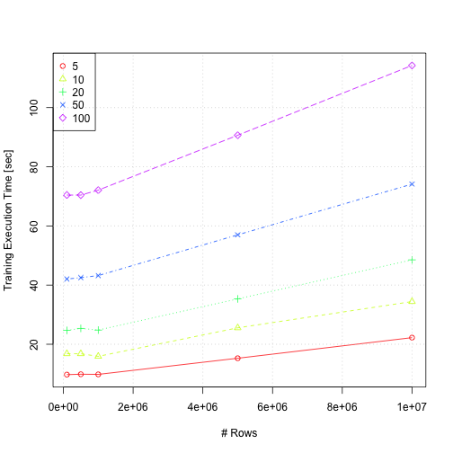

| maxCores | numClusters | trainMilliSec | dimension | rows | numPartitions | sec |
| --- | --- | --- | --- | --- | --- | --- |
| 160 | 5 | 9731 | 100 | 1e+05 | 160 | 9.731 |
| 160 | 10 | 16798 | 100 | 1e+05 | 160 | 16.798 |
| 160 | 20 | 24684 | 100 | 1e+05 | 160 | 24.684 |
| 160 | 50 | 42054 | 100 | 1e+05 | 160 | 42.054 |
| 160 | 100 | 70436 | 100 | 1e+05 | 160 | 70.436 |
| 160 | 5 | 9865 | 100 | 5e+05 | 160 | 9.865 |
| 160 | 10 | 16797 | 100 | 5e+05 | 160 | 16.797 |
| 160 | 20 | 25367 | 100 | 5e+05 | 160 | 25.367 |
| 160 | 50 | 42513 | 100 | 5e+05 | 160 | 42.513 |
| 160 | 100 | 70424 | 100 | 5e+05 | 160 | 70.424 |
| 160 | 5 | 9815 | 100 | 1e+06 | 160 | 9.815 |
| 160 | 10 | 15907 | 100 | 1e+06 | 160 | 15.907 |
| 160 | 20 | 24796 | 100 | 1e+06 | 160 | 24.796 |
| 160 | 50 | 43212 | 100 | 1e+06 | 160 | 43.212 |
| 160 | 100 | 72097 | 100 | 1e+06 | 160 | 72.097 |
| 160 | 5 | 15267 | 100 | 5e+06 | 160 | 15.267 |
| 160 | 10 | 25550 | 100 | 5e+06 | 160 | 25.550 |
| 160 | 20 | 35329 | 100 | 5e+06 | 160 | 35.329 |
| 160 | 50 | 56985 | 100 | 5e+06 | 160 | 56.985 |
| 160 | 100 | 90652 | 100 | 5e+06 | 160 | 90.652 |
| 160 | 5 | 22235 | 100 | 1e+07 | 160 | 22.235 |
| 160 | 10 | 34420 | 100 | 1e+07 | 160 | 34.420 |
| 160 | 20 | 48532 | 100 | 1e+07 | 160 | 48.532 |
| 160 | 50 | 74137 | 100 | 1e+07 | 160 | 74.137 |
| 160 | 100 | 114254 | 100 | 1e+07 | 160 | 114.254 |

Where `maxCores` is the number of execution cores on Apache Spark,`numClusters` is the number of clusters gotten, `trainMilliSec` is the execution time for training in millisecond, `dimension` is the number of dimensions of the vectors which are treated in the clustering algorithm, `rows` is the number of trained vectors, `numPartitions` is the number of partitions of a RDD, `sec` is the execution time for training in second.

## Experiment 2: The Effects of Tne Input Vector's Dimensions

### The Result of Training Execution Time

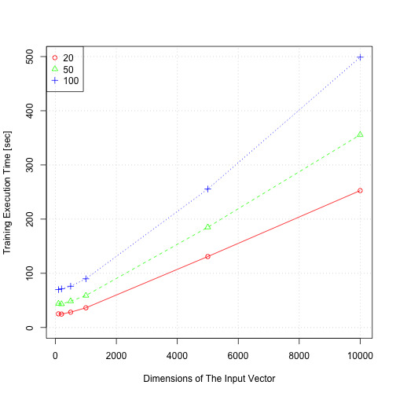

| maxCores | numClusters | trainMilliSec | dimension | rows | numPartitions | sec |
| --- | --- | --- | --- | --- | --- | --- |
| 160 | 20 | 25173 | 100 | 5e+05 | 160 | 25.17 |
| 160 | 50 | 43958 | 100 | 5e+05 | 160 | 43.96 |
| 160 | 100 | 69866 | 100 | 5e+05 | 160 | 69.87 |
| 160 | 20 | 24701 | 200 | 5e+05 | 160 | 24.70 |
| 160 | 50 | 43300 | 200 | 5e+05 | 160 | 43.30 |
| 160 | 100 | 71237 | 200 | 5e+05 | 160 | 71.24 |
| 160 | 20 | 28270 | 500 | 5e+05 | 160 | 28.27 |
| 160 | 50 | 48611 | 500 | 5e+05 | 160 | 48.61 |
| 160 | 100 | 76159 | 500 | 5e+05 | 160 | 76.16 |
| 160 | 20 | 36296 | 1000 | 5e+05 | 160 | 36.30 |
| 160 | 50 | 58941 | 1000 | 5e+05 | 160 | 58.94 |
| 160 | 100 | 89876 | 1000 | 5e+05 | 160 | 89.88 |
| 160 | 20 | 130921 | 5000 | 5e+05 | 160 | 130.92 |
| 160 | 50 | 185020 | 5000 | 5e+05 | 160 | 185.02 |
| 160 | 100 | 255526 | 5000 | 5e+05 | 160 | 255.53 |
| 160 | 20 | 252644 | 10000 | 5e+05 | 160 | 252.64 |
| 160 | 50 | 355632 | 10000 | 5e+05 | 160 | 355.63 |
| 160 | 100 | 498823 | 10000 | 5e+05 | 160 | 498.82 |

## Experiment 3: The Effect of The Number of CPU Cores

### The Result of Training Execution Time

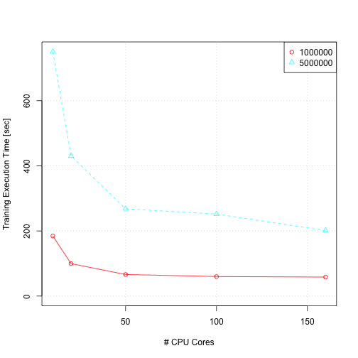

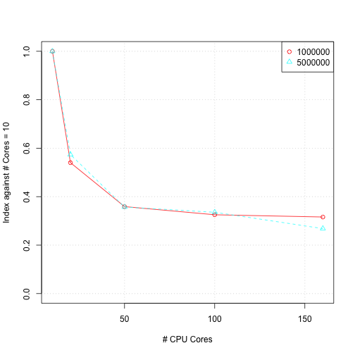

| maxCores | numClusters | trainMilliSec | dimension | rows | numPartitions | sec |
| --- | --- | --- | --- | --- | --- | --- |
| 10 | 20 | 184471 | 1000 | 1e+06 | 10 | 184.47 |
| 20 | 20 | 99672 | 1000 | 1e+06 | 20 | 99.67 |
| 50 | 20 | 66222 | 1000 | 1e+06 | 50 | 66.22 |
| 100 | 20 | 59998 | 1000 | 1e+06 | 100 | 60.00 |
| 160 | 20 | 58293 | 1000 | 1e+06 | 160 | 58.29 |
| 10 | 20 | 750518 | 1000 | 5e+06 | 10 | 750.52 |
| 20 | 20 | 430656 | 1000 | 5e+06 | 20 | 430.66 |
| 50 | 20 | 268077 | 1000 | 5e+06 | 50 | 268.08 |
| 100 | 20 | 251874 | 1000 | 5e+06 | 100 | 251.87 |
| 160 | 20 | 201279 | 1000 | 5e+06 | 160 | 201.28 |

## Experiment 4: The Model Accuracy

I checked the sum of the variance in each cluster. It means good model that the sum of the variance is enough to be low and that the number of given clusters with parameter is equal to that of result clusters.

I know I have to evaluate a hierarichical clustering model with [Cophenic correlation coefficient](http://en.wikipedia.org/wiki/Cophenetic_correlation). However, the cost of the expeirment is very high in order to implement the function to calculate the coefficient. R and SciPy seems to have the way to calculating the coefficient. But it seemd to be difficult to apply my implementation result to them.

### Experimental Procedure

1. Generate the random data set with seed vector
2. Apply the generated data to the hierarchical clustering algorithm
3. Check the number of vectors and the variance of the each result cluster

### Sample Experiment Result

Following sample experiment result means my implementation is good. Because the variances of each cluster is very low and the number of vectors in each cluster is equal to that generated seed vectors.

Other experimental result are refered at Appendix B.

`Count` at `Result Vectors and Their Rows` means the nuber of vectors in each cluster. `Variance` at `Result Vectors and Their Rows` means the sum of the variances for all dimension of each cluster. `Vector` at `Result Vectors and Their Rows` means the head three element of the center of each cluster. In short, it is good that the vector is nearly equal to its seed vector.

`Count` at `Seed Vectors and Their Rows` means the number of generated vectors of each cluster. `Seed Vector` at `Seed Vectors and Their Rows` means the head three elements of the seed vector of each cluster.

```r
==== Experiment Result ====
Total Rows: 15000
Given # Clusters: 5
Result Clusters: 5
Dimension: 5
Train Time: 11826 [msec]
Predict Time: 1114 [msec]
Mean Standard Deviation: 0.009532946302308195
== Result Vectors and Their Rows:
  Count: 1000, Depth: 3, Variance: 9.09797708163629E-5, Seed Vector: 9.998232636083015,10.000264494996959,9.999077138595085...
  Count: 2000, Depth: 3, Variance: 9.087003375841058E-5, Seed Vector: 19.998142831130124,20.000200624447007,19.999131896133836...
  Count: 3000, Depth: 2, Variance: 9.087733230260104E-5, Seed Vector: 29.998172766114426,30.00022191463034,29.99911364362091...
  Count: 4000, Depth: 2, Variance: 9.088058776931782E-5, Seed Vector: 39.998187733606564,40.00023255972202,39.99910451736445...
  Count: 5000, Depth: 2, Variance: 9.085635834442279E-5, Seed Vector: 49.9981607921207,50.000213398557044,49.99912094462609...
== Seed Vectors and Their Rows:
  Count: 1000, Seed Vector: 10.0,10.0,10.0...
  Count: 2000, Seed Vector: 20.0,20.0,20.0...
  Count: 3000, Seed Vector: 30.0,30.0,30.0...
  Count: 4000, Seed Vector: 40.0,40.0,40.0...
  Count: 5000, Seed Vector: 50.0,50.0,50.0...
```

## Experiment 5: The Effects of Vector Sparsity

I verified the effect of vetor sparsity at the divisive hierarchical clustering. Basically speaking, the more sparsity-proportion decreases, the more the training execution time decrease. However, if the sparsity is small too, the time increases. Because it is difficult to split a cluster to good clusters and the many bisecting retries are executed.

### Experimental Setup

I execute the hierarchical clustering, changing the some parameters as bellow. The data had been generated randomly. And then I measured the execution time for training each model.

- # Used Cores: 160
- # Clusters: 20
- # Rows: 100000, 500000
- # Dimensions: 10000
- Sparsity-Proportion: 0.001, 0.01, 0.1, 0.2, 0.5, 1.0

Where `Sparsity-Proportion` means a ratio of active elements againt vector size. There are a few example to explain sparsity-propotion as below.

```
## This vector means  (1.0, 2.0, 3.0, 4.0, 5.0)
## The sparse-propotion is 1.0
SparseVector(5, ((0, 1.0), (1, 2.0), (2, 3.0), (3, 4.0), (4, 5.0)))

## This vector means  (0.0, 2.0, 0.0, 0.0, 5.0)
## The sparse-propotion is 0.4 (2 active elements / 5 all elements)
SparseVector(5, ((1, 2.0), (4, 5.0)))

## This vector means  (0.0, 2.0, 0.0, 0.0, 0.0)
## The sparse-propotion is 0.2 (1 active elements / 5 all elements)
SparseVector(5, ((1, 2.0)))
```

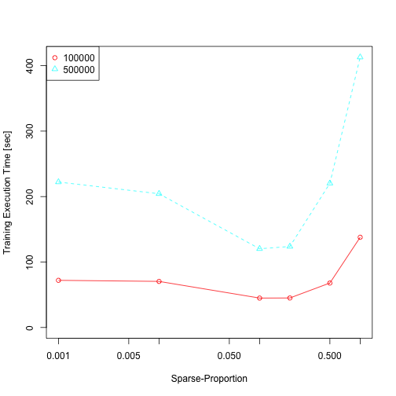

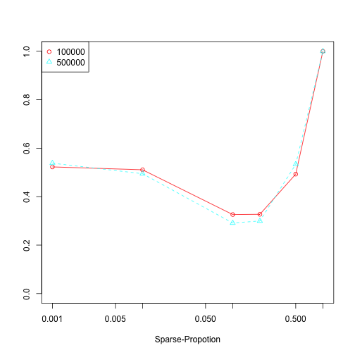

| maxCores | numClusters | trainMilliSec | sparseProportion | dimension | rows | numPartitions | sec |
| --- | --- | --- | --- | --- | --- | --- | --- |
| 160 | 20 | 137819 | 1.000 | 10000 | 1e+05 | 160 | 137.82 |
| 160 | 20 | 67952 | 0.500 | 10000 | 1e+05 | 160 | 67.95 |
| 160 | 20 | 45089 | 0.200 | 10000 | 1e+05 | 160 | 45.09 |
| 160 | 20 | 44942 | 0.100 | 10000 | 1e+05 | 160 | 44.94 |
| 160 | 20 | 70406 | 0.010 | 10000 | 1e+05 | 160 | 70.41 |
| 160 | 20 | 72048 | 0.001 | 10000 | 1e+05 | 160 | 72.05 |
| 160 | 20 | 412930 | 1.000 | 10000 | 5e+05 | 160 | 412.93 |
| 160 | 20 | 220286 | 0.500 | 10000 | 5e+05 | 160 | 220.29 |
| 160 | 20 | 123754 | 0.200 | 10000 | 5e+05 | 160 | 123.75 |
| 160 | 20 | 120261 | 0.100 | 10000 | 5e+05 | 160 | 120.26 |
| 160 | 20 | 204311 | 0.010 | 10000 | 5e+05 | 160 | 204.31 |
| 160 | 20 | 222223 | 0.001 | 10000 | 5e+05 | 160 | 222.22 |

## Discussion

- The more the number of clusters which you want increases, the more the training execution time increases linearly.
- The more the number of input data rows increases, the more the training execution time increases linearly.
- The more the number of CPU cores on the Apache Spark cluster, the more the training execution time decrease. However if the number of CPU cores is large against the input data size, the time is saturant.
- The accuracy of this model is good enough according to `Appendix B`.
- Basically speaking, the more sparsity-proportion decreases, the more the training execution time decrease. However, if the sparsity is small too, the time increases. Because it is difficult to split a cluster to good clusters and the many bisecting retries are executed.

## Appendix A: Spark Cluster Environment

### Runtime Information

| Name | Value |
| --- | --- |
| Java Home | /usr/lib/jvm/java-1.7.0-openjdk-1.7.0.65.x86_64/jre |
| Java Version | 1.7.0_65 (Oracle Corporation) |
| Scala Version | version 2.10.4 |

#### Spark Properties

| Name | Value |
| --- | --- |
| spark.app.name | hierarchical clustering |
| spark.cores.max | 64 |
| spark.driver.host | ip-10-168-49-221.ap-northeast-1.compute.internal |
| spark.driver.port | 35853 |
| spark.executor.extraClassPath | /root/ephemeral-hdfs/conf |
| spark.executor.extraLibraryPath | /root/ephemeral-hdfs/lib/native/ |
| spark.executor.memory | 235520m |
| spark.fileserver.uri | http://10.168.49.221:42810 |
| spark.jars | file:/root/hierarchical-clustering-with-spark/target/scala-2.10/hierarchical-clustering_2.10-0.0.1.jar |
| spark.scheduler.mode | FIFO |
| spark.tachyonStore.folderName | spark-f418d485-90b6-4770-8694-d1721a07e5b6 |

### System Properties

[output not shown]

### Classpath Entries

| Resource | Source ▾ |
| --- | --- |
| http://10.168.49.221:42810/jars/hierarchical-clustering_2.10-0.0.1.jar | Added By User |
| /root/ephemeral-hdfs/conf | System Classpath |
| /root/ephemeral-hdfs/conf | System Classpath |
| /root/spark/conf | System Classpath |
| /root/spark/lib/datanucleus-api-jdo-3.2.1.jar | System Classpath |
| /root/spark/lib/datanucleus-core-3.2.2.jar | System Classpath |
| /root/spark/lib/datanucleus-rdbms-3.2.1.jar | System Classpath |
| /root/spark/lib/spark-assembly-1.1.0-hadoop2.0.0-mr1-cdh4.2.0.jar | System Classpath |

## Appendix B: Otthers Accuracy Test Results

`Count` at `Result Vectors and Their Rows` means the nuber of vectors in each cluster. `Variance` at `Result Vectors and Their Rows` means the sum of the variances for all dimension of each cluster. `Vector` at `Result Vectors and Their Rows` means the head three element of the center of each cluster. In short, it is good that the vector is nearly equal to its seed vector.

`Count` at `Seed Vectors and Their Rows` means the number of generated vectors of each cluster. `Seed Vector` at `Seed Vectors and Their Rows` means the head three elements of the seed vector of each cluster.

### The Number of Dimensions: 5

```
 [1] "==== Experiment Result ===="
 [2] "Total Rows: 15000"
 [3] "Given # Clusters: 5"
 [4] "Result Clusters: 5"
 [5] "Dimension: 5"
 [6] "Train Time: 11826 [msec]"
 [7] "Predict Time: 1114 [msec]"
 [8] "Mean Standard Deviation: 0.009532946302308195"
 [9] "== Result Vectors and Their Rows: "
[10] "  Count: 1000, Depth: 3, Variance: 9.09797708163629E-5, Seed Vector: 9.998232636083015,10.000264494996959,9.999077138595085..."
[11] "  Count: 2000, Depth: 3, Variance: 9.087003375841058E-5, Seed Vector: 19.998142831130124,20.000200624447007,19.999131896133836..."
[12] "  Count: 3000, Depth: 2, Variance: 9.087733230260104E-5, Seed Vector: 29.998172766114426,30.00022191463034,29.99911364362091..."
[13] "  Count: 4000, Depth: 2, Variance: 9.088058776931782E-5, Seed Vector: 39.998187733606564,40.00023255972202,39.99910451736445..."
[14] "  Count: 5000, Depth: 2, Variance: 9.085635834442279E-5, Seed Vector: 49.9981607921207,50.000213398557044,49.99912094462609..."
[15] "== Seed Vectors and Their Rows: "
```

[output cut: 195 more lines]

[output not shown]

[output cut: 195 more lines]

### The Number of Dimensions: 20

```
 [1] "==== Experiment Result ===="
 [2] "Total Rows: 15000"
 [3] "Given # Clusters: 5"
 [4] "Result Clusters: 5"
 [5] "Dimension: 20"
 [6] "Train Time: 13570 [msec]"
 [7] "Predict Time: 16 [msec]"
 [8] "Mean Standard Deviation: 0.043934445144802554"
 [9] "== Result Vectors and Their Rows: "
[10] "  Count: 1000, Depth: 3, Variance: 0.0019317158694351997, Seed Vector: 9.999033735783412,10.000647017173446,10.001005258891967..."
[11] "  Count: 2000, Depth: 3, Variance: 0.001930431378430399, Seed Vector: 19.999122971109763,20.00062026681845,20.001118776186342..."
[12] "  Count: 3000, Depth: 2, Variance: 0.0019302423445797098, Seed Vector: 29.999093226000973,30.00062918360345,30.001080937088233..."
[13] "  Count: 4000, Depth: 2, Variance: 0.0019301378210057733, Seed Vector: 39.99907835344655,40.00063364199595,40.001062017539155..."
[14] "  Count: 5000, Depth: 2, Variance: 0.0019299350217333508, Seed Vector: 49.999105124044476,50.00062561688945,50.00109607272751..."
[15] "== Seed Vectors and Their Rows: "
```

[output cut: 195 more lines]

### The Number of Dimensions: 50

```
 [1] "==== Experiment Result ===="
 [2] "Total Rows: 15000"
 [3] "Given # Clusters: 5"
 [4] "Result Clusters: 5"
 [5] "Dimension: 50"
 [6] "Train Time: 11275 [msec]"
 [7] "Predict Time: 1153 [msec]"
 [8] "Mean Standard Deviation: 0.010103451616896022"
 [9] "== Result Vectors and Their Rows: "
[10] "  Count: 1000, Depth: 3, Variance: 1.0213856913156814E-4, Seed Vector: 10.00019047275334,10.000032751613974,9.999201260540127..."
[11] "  Count: 2000, Depth: 3, Variance: 1.0209999721249441E-4, Seed Vector: 20.00014715842064,19.999968364504966,19.99918836933038..."
[12] "  Count: 3000, Depth: 2, Variance: 1.0208005711596925E-4, Seed Vector: 30.000161596531512,29.999989826874657,29.99919266640031..."
[13] "  Count: 4000, Depth: 2, Variance: 1.0206961878599838E-4, Seed Vector: 40.00016881558694,40.0000005580595,39.99919481493527..."
[14] "  Count: 5000, Depth: 2, Variance: 1.0206776171518485E-4, Seed Vector: 50.000155821287116,49.9999812419268,49.9991909475723..."
[15] "== Seed Vectors and Their Rows: "
```

[output cut: 195 more lines]

### The Number of Dimensions: 100

```
 [1] "==== Experiment Result ===="
 [2] "Total Rows: 15000"
 [3] "Given # Clusters: 5"
 [4] "Result Clusters: 5"
 [5] "Dimension: 100"
 [6] "Train Time: 12099 [msec]"
 [7] "Predict Time: 1266 [msec]"
 [8] "Mean Standard Deviation: 0.010090645816011485"
 [9] "== Result Vectors and Their Rows: "
[10] "  Count: 1000, Depth: 3, Variance: 1.0185592153035962E-4, Seed Vector: 10.000744164322063,10.001593629189527,9.999447672896398..."
[11] "  Count: 2000, Depth: 3, Variance: 1.0185353022566313E-4, Seed Vector: 20.00061311919157,20.001596602393526,19.999490937491533..."
[12] "  Count: 3000, Depth: 2, Variance: 1.0182139912883321E-4, Seed Vector: 30.00065680090172,30.001595611325524,29.999476515959817..."
[13] "  Count: 4000, Depth: 2, Variance: 1.0180494968102378E-4, Seed Vector: 40.00067864175681,40.00159511579149,39.99946930519396..."
[14] "  Count: 5000, Depth: 2, Variance: 1.0181400333411411E-4, Seed Vector: 50.000639328217666,50.001596007752674,49.999482284572494..."
[15] "== Seed Vectors and Their Rows: "
```

[output cut: 195 more lines]

### The Number of Dimensions: 200

```
 [1] "==== Experiment Result ===="
 [2] "Total Rows: 15000"
 [3] "Given # Clusters: 5"
 [4] "Result Clusters: 5"
 [5] "Dimension: 200"
 [6] "Train Time: 12500 [msec]"
 [7] "Predict Time: 2063 [msec]"
 [8] "Mean Standard Deviation: 0.009968650094625494"
 [9] "== Result Vectors and Their Rows: "
[10] "  Count: 1000, Depth: 3, Variance: 9.941156519560126E-5, Seed Vector: 9.998581416268967,9.99911137475553,9.999715402951711..."
[11] "  Count: 2000, Depth: 3, Variance: 9.94035454712372E-5, Seed Vector: 19.998542394859985,19.999172728578827,19.999768531348735..."
[12] "  Count: 3000, Depth: 2, Variance: 9.937430153823744E-5, Seed Vector: 29.99855540199632,29.999152277304407,29.999750821883055..."
[13] "  Count: 4000, Depth: 2, Variance: 9.93592222668762E-5, Seed Vector: 39.998561905564486,39.99914205166719,39.99974196715021..."
[14] "  Count: 5000, Depth: 2, Variance: 9.936626416317203E-5, Seed Vector: 49.99855019914177,49.99916045781417,49.999757905669284..."
[15] "== Seed Vectors and Their Rows: "
```

[output cut: 195 more lines]

### The Number of Dimensions: 1000

```
 [1] "==== Experiment Result ===="
 [2] "Total Rows: 15000"
 [3] "Given # Clusters: 5"
 [4] "Result Clusters: 5"
 [5] "Dimension: 1000"
 [6] "Train Time: 11723 [msec]"
 [7] "Predict Time: 1291 [msec]"
 [8] "Mean Standard Deviation: 0.009975488137697018"
 [9] "== Result Vectors and Their Rows: "
[10] "  Count: 1000, Depth: 3, Variance: 9.95694502694559E-5, Seed Vector: 10.000454304685306,10.00106131462623,10.000620928360517..."
[11] "  Count: 2000, Depth: 3, Variance: 9.952939140868238E-5, Seed Vector: 20.000412713554528,20.00101905597663,20.000672829392244..."
[12] "  Count: 3000, Depth: 2, Variance: 9.951064503133267E-5, Seed Vector: 30.00042657726478,30.001033142193148,30.000655529048355..."
[13] "  Count: 4000, Depth: 2, Variance: 9.9500862782882E-5, Seed Vector: 40.000433509119894,40.00104018530141,40.00064687887641..."
[14] "  Count: 5000, Depth: 2, Variance: 9.949836689353242E-5, Seed Vector: 50.00042103178066,50.00102750770656,50.00066244918593..."
[15] "== Seed Vectors and Their Rows: "
```

[output cut: 255 more lines]